# 第 11 章 集成学习

坦率地说，面对预测任务时，在各种机器学习工具之间确定最佳选择并不容易：惩罚回归、树方法、神经网络、SVM 等等。一个自然且诱人的替代方案，是**组合**多个算法（或它们产生的预测），试图从每个引擎（或学习器）中提取价值。这一想法并不新，对这一目标的贡献至少可以追溯到 Bates 和 Granger（1969）（用于旅客流量预测）。

下面，我们列出几本关于集成的书籍。集成有很多名称和同义说法，例如**预测聚合、模型平均、专家混合**或**预测组合**。下面前四篇参考文献是专著，后两篇是论文合集：

- Zhou（2012）：一本非常有教学性的书，覆盖集成的主要思想；
- Schapire 和 Freund（2012）：关于 boosting（因此也是集成）的主要参考，包含许多理论结果，具有坚实的数学基础；
- Seni 和 Elder（2010）：主要面向树方法的入门介绍；
- Claeskens 和 Hjort（2008）：关于模型选择技术的概览，其中有几章聚焦于模型平均；
- Zhang 和 Ma（2012）：关于集成学习的专题章节合集；
- Okun、Valentini 和 Re（2011）：集成应用示例。

本章介绍集成学习的基本思想，更深入的讨论可参考上述书籍。前文已经提到并介绍过若干集成方法，尤其是在第 6 章；随机森林和提升树本身就是集成模型。学习器组合方面的早期研究还包括 Schapire（1990）、Jacobs 等（1991）（尤其针对神经网络）以及 Freund 和 Schapire（1997）。集成方法也可聚合基于不同数据集构建的模型（Pesaran 和 Pick（2011）），还可以扩展为随时间变化的形式（Sun 等（2020））。具有贝叶斯视角的集成理论可参见 Razin 和 Levy（2020）；与资产定价和因子建模相关的讨论则见 Gospodinov 和 Maasoumi（2020）以及 De Nard、Hediger 和 Leippold（2020）（子采样与预测聚合）。

## 11.1 线性集成

### 11.1.1 原理

本章采用如下记号。我们处理 $M$ 个模型，其中 $\tilde{y}_{i,m}$ 是模型 $m$ 对样本 $i$ 的预测，误差 $\epsilon_{i,m}=y_i-\tilde{y}_{i,m}$ 被堆叠成一个 $(I\times M)$ 矩阵 $\mathbf{E}$。模型线性组合的样本误差为 $\textbf{Ew}$，其中 $\textbf{w}=w_m$ 是分配给各模型的权重，并满足约束 $\textbf{w}'\textbf{1}_M=1$。因此，最小化总平方误差是一个简单的二次规划问题，唯一约束仍为 $\textbf{w}'\textbf{1}_M=1$。写出相应的拉格朗日函数可得

\begin{align} \frac{\partial}{\partial \textbf{w}}L(\textbf{w})=\textbf{E}'\textbf{E}\textbf{w}-\lambda \textbf{1}_M=0 \quad \Leftrightarrow \quad \textbf{w}=\lambda(\textbf{E}'\textbf{E})^{-1}\textbf{1}_M, \end{align}

约束给出 $\textbf{w}^*=\frac{(\textbf{E}'\textbf{E})^{-1}\textbf{1}_M}{(\textbf{1}_M'\textbf{E}'\textbf{E})^{-1}\textbf{1}_M}$。这种形式类似于最小方差投资组合。如果误差无偏，即 $\textbf{1}_I'\textbf{E}=\textbf{0}_M'$，则 $\textbf{E}'\textbf{E}$ 与误差的样本协方差矩阵仅相差一个不影响最优权重的比例因子。

该表达式展示了优化线性集成的一个重要特征：只有当模型讲述不同故事时，它们才可能增加价值。如果两个模型冗余，$\textbf{E}'\textbf{E}$ 会接近奇异，$\textbf{w}^*$ 会以虚假的方式在二者之间套利。这与用高度相关资产构建均值-方差组合时遇到的问题完全相同：在这种情况下，分散化失败，因为一旦出错，所有资产都会下跌。当观测数量相对于资产数量过少、导致收益协方差矩阵奇异时，也会出现另一个问题。这对集成不是问题，因为观测数量通常远大于模型数量（$I>>M$）。

当相关性趋近于一时，上述形式会变得高度不稳定，集成也不可信。一个启发式理解方式是令 $M=2$，并有

$\textbf{E}'\textbf{E}=\left[ \begin{array}{cc} \sigma_1^2 & \rho\sigma_1\sigma_2 \\ \rho\sigma_1\sigma_2 & \sigma_2^2 \\ \end{array} \right] \quad \Leftrightarrow \quad (\textbf{E}'\textbf{E})^{-1}=\frac{1}{1-\rho^2}\left[ \begin{array}{cc} \sigma_1^{-2} & -\rho(\sigma_1\sigma_2)^{-1} \\ -\rho(\sigma_1\sigma_2)^{-1} & \sigma_2^{-2} \\ \end{array} \right]$

因此，当 $\rho \rightarrow 1$ 时，误差方差较小的模型（即 $\sigma_i^2$ 较小者）会得到趋于无穷大的正权重，另一个模型则得到绝对值同样巨大的**负权重**。这相当于用极端正负头寸在两个高度相关的模型之间构造多空对冲，结果对很小的估计误差都极为敏感，因而并不稳健。

还可以从另一个角度理解相关性的影响。假设有 $M$ 个相关误差 $\epsilon_m$，两两相关系数为 $\rho$，均值为零、方差为 $\sigma^2$。等权平均误差的方差为

\begin{align*} \mathbb{E}\left[\frac{1}{M}\sum_{m=1}^M \epsilon_m^2 \right]&=\frac{1}{M^2}\left[\sum_{m=1}^M\epsilon_m^2+\sum_{m\neq n}\epsilon_n\epsilon_m\right] \\ &=\frac{\sigma^2}{M}+\frac{1}{M^2}\sum_{n\neq m} \rho \sigma^2 \\ & =\rho \sigma^2 +\frac{\sigma^2(1-\rho)}{M} \end{align*}

其中第二项随 $M$ 增加而收敛到零，但第一项保留下来，并随 $\rho$ **线性增加**。顺便说一句，由于方差总为正，这一结果意味着 $M$ 个变量之间共同的两两相关系数下界为 $-(M-1)^{-1}$。这个结果很有意思，但教科书中很少见。

为规避相关性造成的问题，Breiman（1996）这篇开创性论文倡议的一项改进，是对权重强制施加非负约束，并求解

\begin{align} \underset{\textbf{w}}{\text{argmin}} \ \textbf{w}'\textbf{E}'\textbf{E}\textbf{w} , \quad \text{s.t.} \quad \left\{ \begin{array}{l} \textbf{w}'\textbf{1}_M=1 \\ w_m \ge 0 \quad \forall m \end{array}\right. . \end{align}

从机制上看，如果若干模型高度相关，该约束会使其中只有一个模型具有非零权重。如果模型很多，则最小化程序只会选择其中少数几个。在组合优化语境中，Jagannathan 和 Ma（2003）展示了约束在构建均值-方差配置时具有反直觉的好处。在我们的设定中，约束同样会帮助明智地区分“最好”的模型。

在文献中，预测组合和模型平均（它们是集成的同义词）早在 Von Holstein（1972）中就已在股票市场上测试。令人意外的是，这些文章并未发表在金融期刊，而是发表在管理学（Virtanen 和 Yli-Olli（1987）、Wang 等（2012））、经济学与计量经济学（Donaldson 和 Kamstra（1996）、Clark 和 McCracken（2009）、Mascio、Fabozzi 和 Zumwalt（2020））、运筹学（Huang、Nakamori 和 Wang（2005）、Leung、Daouk 和 Chen（2001），以及 Bonaccolto 和 Paterlini（2019））以及计算机科学（Harrald 和 Kamstra（1997）、Hassan、Nath 和 Kirley（2007））等领域。

在一般预测文献中，人们研究了许多用于组合预测的替代（精细化）方法。截尾意见池（Grushka-Cockayne、Jose 和 Lichtendahl Jr（2016））会对不太极端的预测取平均。Pike 和 Vazquez-Grande（2020）发展了权重依赖于过去误差的集成。关于组合方法更完整的列表以及其效率的实证研究，可参见 Gaba、Tsetlin 和 Winkler（2017）。最后，关于模型平均与模型选择的理论讨论，可参见 Peng 和 Yang（2021）。总体而言，研究发现并不一致，而启发式的简单平均一如既往地难以击败（见例如 Genre 等（2013））。

### 11.1.2 示例

为了构建一个集成，我们必须把预测及相应误差收集到 $\mathbf{E}$ 矩阵中。我们将使用前几章训练过的 5 个模型：惩罚回归、简单树、随机森林、xgboost 和前馈神经网络。训练误差均值为零，因此 $\textbf{E}'\textbf{E}$ 是模型间误差的协方差矩阵。

```python
import pandas as pd
import numpy as np
err_pen_train = fit_pen_pred.predict(X_penalized_train)-training_sample['R1M_Usd']          # Reg.
err_tree_train = fit_tree.predict(training_sample[features])-training_sample['R1M_Usd']     # Tree
err_RF_train = fit_RF.predict(training_sample[features])-training_sample['R1M_Usd']         # RF
err_XGB_train = fit_xgb.predict(train_matrix_xgb)-training_sample['R1M_Usd']                # XGBoost
err_NN_train = model_NN.predict(training_sample[features_short])-training_sample['R1M_Usd'].values.reshape((-1,1))  # NN
E= pd.concat([err_pen_train, err_tree_train,err_RF_train,err_XGB_train,pd.DataFrame(err_NN_train)], axis=1)   # E matrix
E.set_axis(['Pen_reg','Tree','RF','XGB','NN'], axis=1, inplace=True)                            # Names
E.corr()                                                                                        # Cor. mat.
```

|  | Pen_reg | Tree | RF | XGB | NN |
| --- | --- | --- | --- | --- | --- |
| Pen_reg | 1.000000 | 0.998439 | 0.989132 | 0.982260 | 0.998416 |
| Tree | 0.998439 | 1.000000 | 0.990692 | 0.984177 | 0.998498 |
| RF | 0.989132 | 0.990692 | 1.000000 | 0.978393 | 0.990739 |
| XGB | 0.982260 | 0.984177 | 0.978393 | 1.000000 | 0.984303 |
| NN | 0.998416 | 0.998498 | 0.990739 | 0.984303 | 1.000000 |

```python
E.corr().mean()
```

```
Pen_reg    0.993649
Tree       0.994361
RF         0.989791
XGB        0.985826
NN         0.994391
dtype: float64
```

相关矩阵显示，这些模型未能在预测中产生异质性。最低相关性（尽管也高于 95%！）来自提升树模型。下面，我们通过计算误差绝对值的平均值来比较模型的训练准确性。

```python
abs(E).mean() # Mean absolute error or columns of E
```

```
Pen_reg    0.083459
Tree       0.083621
RF         0.074806
XGB        0.084048
NN         0.083627
dtype: float64
```

```python
w_ensemble = np.linalg.inv((E.T.values@E.values))@np.ones(5)                    # Optimal weights
w_ensemble /= np.sum(w_ensemble)
w_ensemble
```

```
array([ 1.02220538, -2.22814584,  3.93749133,  0.56469433, -2.29624521])
```

注意，权重当然是用**训练误差**计算的。随后在测试样本上测试最优组合。下面，我们计算样本外（测试）误差及其绝对值均值。

```python
err_pen_test = fit_pen_pred.predict(X_penalized_test)-testing_sample['R1M_Usd']          # Reg.
err_tree_test = fit_tree.predict(testing_sample[features])-testing_sample['R1M_Usd']     # Tree
err_RF_test = fit_RF.predict(testing_sample[features])-testing_sample['R1M_Usd']         # RF
err_XGB_test = fit_xgb.predict(test_matrix_xgb)-testing_sample['R1M_Usd']                # XGBoost
err_NN_test = model_NN.predict(testing_sample[features_short])-testing_sample['R1M_Usd'].values.reshape((-1,1))  # NN
E_test= pd.concat([err_pen_test, err_tree_test,err_RF_test,err_XGB_test,pd.DataFrame(err_NN_test,index=testing_sample.index)], axis=1)   # E_test matrix
E_test.set_axis(['Pen_reg','Tree','RF','XGB','NN'], axis=1, inplace=True)                       # Names
abs(E_test).mean() # Mean absolute error or columns of E_test
```

```
Pen_reg    0.066182
Tree       0.066535
RF         0.067986
XGB        0.068569
NN         0.066613
dtype: float64
```

提升树模型仍然是表现最差的算法，而简单模型（回归和简单树）表现最好。最朴素的组合是模型和预测的简单平均。

```python
err_EW_test = np.mean(np.abs(E_test.mean(axis=1))) # equally weight combination
print(f'equally weight combination: {err_EW_test}')
```

```
equally weight combination: 0.06673125663086175
```

由于误差高度相关，预测的等权组合产生的平均误差位于单个误差的“中间”。分散化收益太小。现在测试“最优”组合 $\textbf{w}^*=\frac{(\textbf{E}'\textbf{E})^{-1}\textbf{1}_M}{(\textbf{1}_M'\textbf{E}'\textbf{E})^{-1}\textbf{1}_M}$。

```python
err_opt_test =np.mean(np.abs(E_test.values@w_ensemble)) # Optimal unconstrained combination
print(f'Optimal unconstrained combination: {err_opt_test}')
```

```
Optimal unconstrained combination: 0.08351002385399925
```

结果再次令人失望，原因是模型之间缺乏分散化。不仅训练样本上的误差相关性很高，测试样本上的误差相关性也很高，如下所示。

```python
E_test.corr()                                                                              # Cor. mat.
```

|  | Pen_reg | Tree | RF | XGB | NN |
| --- | --- | --- | --- | --- | --- |
| Pen_reg | 1.000000 | 0.998707 | 0.991539 | 0.966304 | 0.998564 |
| Tree | 0.998707 | 1.000000 | 0.993818 | 0.968991 | 0.998854 |
| RF | 0.991539 | 0.993818 | 1.000000 | 0.972710 | 0.993923 |
| XGB | 0.966304 | 0.968991 | 0.972710 | 1.000000 | 0.969315 |
| NN | 0.998564 | 0.998854 | 0.993923 | 0.969315 | 1.000000 |

最优解带来的杠杆只会加剧问题，并且表现逊于启发式的均匀组合。本节最后给出 Breiman（1996）二次优化的有约束形式。如果用 $\mathbf{\Sigma}$ 表示误差协方差矩阵，我们要求解

\begin{align} \mathbf{w}^*=\underset{\mathbf{w}}{\text{argmin}} \ \mathbf{w}'\mathbf{\Sigma}\mathbf{w}, \quad \mathbf{1}'\mathbf{w}=1, \quad w_i\ge 0, \end{align}

约束将按如下方式处理：

\begin{align} \mathbf{A} \mathbf{w}= \begin{bmatrix} 1 & 1 & 1 \\ 1 & 0 & 0\\ 0 & 1 & 0 \\ 0 & 0 & 1 \end{bmatrix} \mathbf{w} \hspace{9mm} \text{ compared to} \hspace{9mm} \mathbf{b}=\begin{bmatrix} 1 \\ 0 \\ 0 \\ 0 \end{bmatrix}, \end{align}

其中第一行是等式（权重之和为一），最后三行是不等式（所有权重为正）。

```python
from cvxopt import matrix, solvers                    # Library for quadratic programming
sigma = E.T.values@E.values                           # Unscaled covariance matrix
nb_mods= 5                                            # Number of models
Q = 2*matrix(sigma, tc="d")                           # Symmetric quadratic-cost matrix
p = matrix(np.zeros(nb_mods),tc="d")                  # Quadratic-cost vector
G = matrix(-np.eye(nb_mods), tc="d")                  # Linear inequality constraint matrix
h = matrix(np.zeros(nb_mods), tc="d")                 # Linear inequality constraint vector
A = matrix(np.ones(nb_mods), (1, nb_mods))            # matrix for linear equality constraint
b = matrix(1.0)                                       # vector for linear equality constraint
w_const=solvers.qp(Q, p, G, h, A, b)                  # Solution
print(w_const['x']) # Solution
```

```
     pcost       dcost       gap    pres   dres
 0:  3.3445e+03  3.3656e+03  5e+01  7e+00  1e+01
 1:  3.3575e+03  3.4486e+03  2e+01  4e+00  6e+00
 2:  3.4155e+03  3.5580e+03  2e+01  2e+00  4e+00
 3:  3.5873e+03  4.1600e+03  3e+02  2e+00  3e+00
 4:  3.9350e+03  4.4186e+03  2e+02  1e+00  2e+00
 5:  5.2828e+03  4.1593e+03  2e+03  8e-01  1e+00
 6:  4.9769e+03  4.6678e+03  3e+02  3e-16  2e-11
 7:  4.7556e+03  4.7111e+03  4e+01  1e-16  3e-12
 8:  4.7238e+03  4.7233e+03  6e-01  1e-16  5e-12
 9:  4.7234e+03  4.7234e+03  6e-03  2e-16  4e-12
10:  4.7234e+03  4.7234e+03  6e-05  4e-16  4e-12
Optimal solution found.
[ 5.66e-09]
[ 5.68e-09]
[ 1.00e+00]
[ 6.34e-08]
[ 5.70e-09]
```

与无约束解相比，权重是稀疏的，并集中在一个模型上，通常是训练样本误差较小的模型。

## 11.2 堆叠集成

### 11.2.1 两阶段训练

**堆叠集成**是线性集成的自然推广。推广线性集成的想法至少可以追溯到 Wolpert（1992b）。在一般情形中，训练分为两个阶段。第一阶段很简单：$M$ 个模型独立训练，得到模型 $m$ 对样本 $i$ 的预测 $\tilde{y}_{i,m}$。第二步是把训练好模型的输出作为新一层机器学习优化的输入。第二层预测为 $\breve{y}_i=h(\tilde{y}_{i,1},\dots,\tilde{y}_{i,M})$，其中 $h$ 是一个新的学习器（见图 11.1）。线性集成当然也是堆叠集成，只不过其第二层是线性回归。

随后应用同样的技术，最小化真实值 $y_i$ 与预测值 $\breve{y}_i$ 之间的误差。

[figure not shown]

图 11.1：堆叠集成示意图。

### 11.2.2 代码与结果

下面，我们创建一个低维神经网络，它接收每个模型的单独预测，并将它们汇总为一个合成预测。

```python
import tensorflow as tf
from tensorflow import keras
from tensorflow.keras import layers
from plot_keras_history import show_history

model_stack = keras.Sequential() # This defines the structure of the network, i.e. how layers are organized
model_stack.add(layers.Dense(8, activation="relu", input_shape=(nb_mods,)))
model_stack.add(layers.Dense(4, activation="tanh"))
model_stack.add(layers.Dense(1))
```

该配置非常简单，没有加入额外的正则化参数，因此模型可能过拟合。由于目标是预测收益率，损失函数采用标准 $L^2$ 损失。

```python
model_stack.compile(optimizer='RMSprop',                        # Optimisation method (weight updating)
              loss='mse',                                       # Loss function
              metrics=['MeanAbsoluteError'])                    # Output metric
model_stack.summary()                                           # Model architecture
```

```
Model: "sequential_1"
_________________________________________________________________
 Layer (type)                Output Shape              Param #
=================================================================
 dense_3 (Dense)             (None, 8)                 48

 dense_4 (Dense)             (None, 4)                 36

 dense_5 (Dense)             (None, 1)                 5

=================================================================
Total params: 89
Trainable params: 89
Non-trainable params: 0
_________________________________________________________________
```

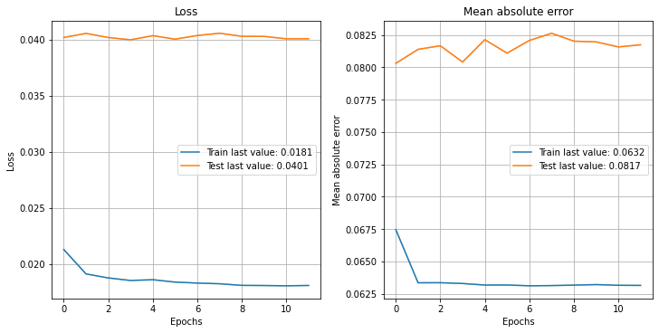

```python
y_tilde = E.values + np.tile(training_sample['R1M_Usd'].values.reshape(-1, 1), nb_mods)    # Train preds
y_test = E_test.values + np.tile(testing_sample['R1M_Usd'].values.reshape(-1, 1), nb_mods) # Testing
fit_NN_stack  = model_stack.fit(y_tilde,                            # Train features
                          NN_train_labels,                          # Train labels
                          batch_size=512,                           # Train parameters
                          epochs=12,                                # Train parameters
                          verbose=1,                                # Show messages
                          validation_data=(y_test,NN_test_labels))  # Test features & labels
show_history(fit_NN_stack )                                         # Show training plot
```

图 11.2：集成模型的训练指标。

集成模型的表现再次令人失望：图 11.2 中的学习曲线是平的，因此多轮反向传播没有用。训练几乎没有增加价值，这意味着新的上层机器学习层没有增强原始预测。原因仍然是，所有机器学习引擎似乎都在捕捉相同模式，无论线性组合还是非线性组合都未能提升表现。

### 11.3 扩展

### 11.3.1 宏观条件化

在金融语境中，宏观经济指标可能为这一过程增加价值。某些模型可能在特定条件下表现更好，而外生预测变量可以帮助在预测中引入一种**经济驱动的条件性**。

把宏观变量加入预测变量集合（这里是预测值）$\tilde{y}_{i,m}$ 似乎是一种实现方式。然而，这相当于把预测值与（可能经过缩放的）经济指标混合在一起，并不太有意义。

集成范围之外的一个替代方案，是在一组宏观经济指标上训练简单树。如果标签是来自原始预测的（可能取绝对值的）误差，那么树会生成误差值同质的簇。这会提示哪些条件导致最好和最差预测。下面我们使用圣路易斯联邦储备银行的汇总数据测试这一想法。我们在下一个代码块下载并格式化数据。

```python
macro_cond = pd.read_csv("macro_cond.csv")                                           # Term Spred, Inflation and Consumer Price Index
macro_cond["Index"] = pd.to_datetime(macro_cond["date"]) + pd.offsets.MonthBegin(-1) # Change date to first day of month to join/merge
ens_data=pd.DataFrame()
ens_data['date'] = testing_sample["date"].values
ens_data['err_NN_test'] = err_NN_test                                        # Using the errors from previous section
ens_data["Index"] = pd.to_datetime(ens_data["date"]) + pd.offsets.MonthBegin(-1)     # Change date to first day of month to join/merge
ens_data = pd.merge(ens_data, macro_cond, how="left", left_on="Index", right_on="Index")
ens_data.head()                                                                      # Show first lines
```

|  | date_x | err_NN_test | Index | date_y | CPIAUCSL | inflation | termspread |
| --- | --- | --- | --- | --- | --- | --- | --- |
| 0 | 2014-01-31 | 0.084440 | 2014-01-01 | 31/01/2014 | 235.288 | 0.002424 | 2.47 |
| 1 | 2014-01-31 | 0.073821 | 2014-01-01 | 31/01/2014 | 235.288 | 0.002424 | 2.47 |
| 2 | 2014-01-31 | -0.254902 | 2014-01-01 | 31/01/2014 | 235.288 | 0.002424 | 2.47 |
| 3 | 2014-01-31 | 0.266475 | 2014-01-01 | 31/01/2014 | 235.288 | 0.002424 | 2.47 |
| 4 | 2014-01-31 | -0.079414 | 2014-01-01 | 31/01/2014 | 235.288 | 0.002424 | 2.47 |

现在可以构建一棵树，尝试用宏观变量解释模型准确性。

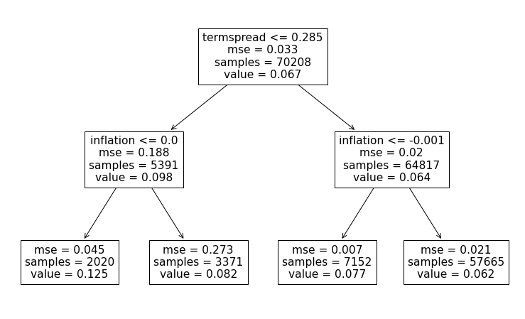

```python
X_ens = ens_data[['inflation','termspread']]                                         # Training macro features
y_ens = abs(ens_data['err_NN_test'])                                                 # Label, here error from previous section
fit_ens  = tree.DecisionTreeRegressor(                                               # Definining the model
  max_depth = 2,                                                                     # Maximum depth (i.e. tree levels)
  ccp_alpha=0.00001                                                                  # complexity parameters
        )
fit_ens.fit(X_ens, y_ens)                                                            # Fitting the model
fig, ax = plt.subplots(figsize=(13, 8))                                              # resizing
tree.plot_tree(fit_ens ,feature_names=X_ens.columns.values, ax=ax)                   # Plot the tree
plt.show()
```

图 11.3：机器学习引擎的条件表现。

### 11.3.2 降低模型间相关性

如本章前文所示，当第一层预测高度相关时，集成会出现一个主要问题。在这种情况下，集成基本没用。有几种技巧可以帮助降低这种相关性，但最简单也最好的办法可能是改变训练样本。如果算法看到的不是同一批数据，它们很可能推断出不同模式。

拆分训练数据、构造不同训练样本子集有多种方式。第一组二分是随机拆分与确定性拆分。随机拆分很容易，只需要固定目标样本大小。注意，只要重叠不太大，训练样本可以重叠。因此，如果原始训练样本有  
$I$ 个样本，而集成需要 $M$ 个模型，那么子样本大小 $\lfloor I/M \rfloor$ 可能过于保守，尤其是在训练样本不大的时候。此时，$\lfloor I/\sqrt{M} \rfloor$ 可能是更好的替代方案。随机森林就是基于随机训练样本构建的集成示例。

确定性拆分的一个优点是容易复现，其结果不依赖随机种子。基于因子的训练样本的性质决定了第二组拆分二分：按时间拆分与按资产拆分。按资产拆分很直接：每个模型在不同股票集合上训练。注意，集合的选择可以是随机的，也可以由某种因子准则决定：规模、动量、账面市值比等。

按日期拆分需要其他决策：数据是拆分为大区块（如年份）并让每个模型获得一个区块，这个区块可能代表某种特定市场条件吗？还是更规律地划分训练日期？例如，如果集成中有 12 个模型，则每个模型可以在某个月份的数据上训练（如第一个模型用 1 月，第二个模型用 2 月，依此类推）。

下面，我们在四个不同年份上训练四个模型，看看这是否有助于降低模型间相关性。这个过程有点长，因为样本和模型都需要重新定义。我们先创建四个训练样本。第三个模型使用较小的特征子集，因此样本更小。

```python
training_sample_2007 = training_sample.loc[training_sample.index[(
    training_sample['date'] > '2006-12-31') & (training_sample['date'] < '2008-01-01')].tolist()]
training_sample_2009 = training_sample.loc[training_sample.index[(
    training_sample['date'] > '2008-12-31') & (training_sample['date'] < '2010-01-01')].tolist()]
training_sample_2011 = training_sample.loc[training_sample.index[(
    training_sample['date'] > '2010-12-31') & (training_sample['date'] < '2012-01-01')].tolist()]
training_sample_2013 = training_sample.loc[training_sample.index[(
    training_sample['date'] > '2012-12-31') & (training_sample['date'] < '2014-01-01')].tolist()]
```

随后，我们开始训练模型。语法与前几章所用相同，没有新内容。先从惩罚回归开始。在下面所有预测中，原始测试样本**对所有模型**都使用。

```python
y_ens_2007 = training_sample_2007['R1M_Usd'].values                                 # Dep. var.
x_ens_2007 = training_sample_2007[features].values                                  # Predictors
model_2007 = ElasticNet(alpha=0.1, l1_ratio=0.1)                                    # Model
fit_ens_2007=model_2007.fit(x_ens_2007,y_ens_2007)                                  # fitting the model
err_ens_2007 = fit_ens_2007.predict(X_penalized_test)-testing_sample['R1M_Usd']     # Pred. errs
```

接下来是随机森林。

```python
from sklearn.ensemble import RandomForestRegressor
fit_ens_2009 = RandomForestRegressor(n_estimators = 40, # Nb of random trees
criterion ='mse', # function to measure the quality of a split
min_samples_split= 250, # Minimum size of terminal cluster
bootstrap=False, # replacement
max_features=30, # Nb of predictive variables for each tree
max_samples=4000 # Size of (random) sample for each tree
)
fit_ens_2009.fit(training_sample_2009[features].values,training_sample_2009['R1M_Usd'].values ) # Fitting the model
err_ens_2009=fit_ens_2009.predict(pd.DataFrame(X_test))-testing_sample['R1M_Usd'] # Pred. errs
```

第三个模型是提升树。

```python
train_features_xgb_2011=training_sample_2011[features_short].values # Independent variables
train_label_xgb_2011=training_sample_2011['R1M_Usd'].values # Dependent variable
train_matrix_xgb_2011=xgb.DMatrix(train_features_xgb_2011, label=train_label_xgb_2011) # XGB format!

params={'eta' : 0.3,                          # Learning rate
  'objective' : "reg:squarederror",     # Objective function
  'max_depth' : 4,                      # Maximum depth of trees
  'subsample' : 0.6,                    # Train on random 60% of sample
  'colsample_bytree' : 0.7,             # Train on random 70% of predictors
  'lambda' : 1,                         # Penalisation of leaf values
  'gamma' : 0.1}                        # Penalisation of number of leaves
fit_ens_2011 =xgb.train(params, train_matrix_xgb_2011, num_boost_round=18) # Number of trees used
err_ens_2011=fit_ens_2011.predict(test_matrix_xgb)-testing_sample['R1M_Usd'] # Pred. errs
```

最后一个模型是简单神经网络。

```python
model = keras.Sequential()
model.add(layers.Dense(16, activation="relu", input_shape=(len(features),)))
model.add(layers.Dense(8, activation="tanh"))
model.add(layers.Dense(1))
model.compile(optimizer='RMSprop',
              loss='mse',
              metrics=['MeanAbsoluteError'])
model.summary()
fit_ens_2013 = model.fit(
            training_sample_2013[features].values,                  # Training features
            training_sample_2013['R1M_Usd'].values,                 # Training labels
            batch_size=128,                                         # Training parameters
            epochs = 9,                                             # Training parameters
            verbose = True                                          # Show messages
)

err_ens_2013=model.predict(X_penalized_test)-testing_sample['R1M_Usd'].values.reshape((-1,1)) # Pred. errs
```

```
Model: "sequential_2"
_________________________________________________________________
 Layer (type)                Output Shape              Param #
=================================================================
 dense_6 (Dense)             (None, 16)                1504

 dense_7 (Dense)             (None, 8)                 136

 dense_8 (Dense)             (None, 1)                 9

=================================================================
Total params: 1,649
Trainable params: 1,649
Non-trainable params: 0
_________________________________________________________________
```

有了四个模型的误差后，就可以计算它们的相关矩阵。

```python
E_subtraining = pd.concat([err_ens_2007, err_ens_2009,err_ens_2011,pd.DataFrame(err_ens_2013,index=testing_sample.index)], axis=1)         # E_subtraining matrix
E_subtraining.set_axis(['err_ens_2007','err_ens_2009','err_ens_2011','err_ens_2013'], axis=1, inplace=True)   # Names
E_subtraining.corr()
```

|  | err_ens_2007 | err_ens_2009 | err_ens_2011 | err_ens_2013 |
| --- | --- | --- | --- | --- |
| err_ens_2007 | 1.000000 | 0.953756 | 0.868026 | 0.998962 |
| err_ens_2009 | 0.953756 | 1.000000 | 0.842201 | 0.955961 |
| err_ens_2011 | 0.868026 | 0.842201 | 1.000000 | 0.868046 |
| err_ens_2013 | 0.998962 | 0.955961 | 0.868046 | 1.000000 |

```python
E_subtraining.corr().mean()
```

```
err_ens_2007    0.955186
err_ens_2009    0.937980
err_ens_2011    0.894568
err_ens_2013    0.955742
dtype: float64
```

总体结果令人失望。只有一个模型设法提取出与其他模型略有不同的模式，使整体相关性降至 89%。神经网络（基于 2013 年数据）和惩罚回归（2007 年）仍然高度相关。一个可能解释是，模型主要捕捉的是噪声，而不是信号。使用年度收益等长期标签可能有助于改善模型之间的分散化。

## 11.4 练习

基于 3 个完全使用 Keras 训练的神经网络构建一个集成模型。每个网络接收三分之一的预测变量，并分别输出一个二分类结果（是/否或买入/卖出）。再由上层网络汇总这 3 个输出，形成最终决策。请使用 functional API，并在测试集上评估模型表现。

### 参考文献

Bates, John M, and Clive WJ Granger. 1969. “The Combination of Forecasts.” Journal of the Operational Research Society 20 (4): 451–68.

Bonaccolto, Giovanni, and Sandra Paterlini. 2019. “Developing New Portfolio Strategies by Aggregation.” Annals of Operations Research, 1–39.

Breiman, Leo. 1996. “Stacked Regressions.” Machine Learning 24 (1): 49–64.

Claeskens, Gerda, and Nils Lid Hjort. 2008. Model Selection and Model Averaging. Cambridge University Press.

Clark, Todd E, and Michael W McCracken. 2009. “Improving Forecast Accuracy by Combining Recursive and Rolling Forecasts.” International Economic Review 50 (2): 363–95.

De Nard, Gianluca, Simon Hediger, and Markus Leippold. 2020. “Subsampled Factor Models for Asset Pricing: The Rise of Vasa.” SSRN Working Paper 3557957.

Donaldson, R Glen, and Mark Kamstra. 1996. “Forecast Combining with Neural Networks.” Journal of Forecasting 15 (1): 49–61.

Freund, Yoav, and Robert E Schapire. 1997. “A Decision-Theoretic Generalization of on-Line Learning and an Application to Boosting.” Journal of Computer and System Sciences 55 (1): 119–39.

Gaba, Anil, Ilia Tsetlin, and Robert L Winkler. 2017. “Combining Interval Forecasts.” Decision Analysis 14 (1): 1–20.

Genre, Véronique, Geoff Kenny, Aidan Meyler, and Allan Timmermann. 2013. “Combining Expert Forecasts: Can Anything Beat the Simple Average?” International Journal of Forecasting 29 (1): 108–21.

Gospodinov, Nikolay, and Esfandiar Maasoumi. 2020. “Generalized Aggregation of Misspecified Models: With an Application to Asset Pricing.” Journal of Econometrics Forthcoming.

Grushka-Cockayne, Yael, Victor Richmond R Jose, and Kenneth C Lichtendahl Jr. 2016. “Ensembles of Overfit and Overconfident Forecasts.” Management Science 63 (4): 1110–30.

Harrald, Paul G, and Mark Kamstra. 1997. “Evolving Artificial Neural Networks to Combine Financial Forecasts.” IEEE Transactions on Evolutionary Computation 1 (1): 40–52.

Hassan, Md Rafiul, Baikunth Nath, and Michael Kirley. 2007. “A Fusion Model of Hmm, Ann and Ga for Stock Market Forecasting.” Expert Systems with Applications 33 (1): 171–80.

Huang, Wei, Yoshiteru Nakamori, and Shou-Yang Wang. 2005. “Forecasting Stock Market Movement Direction with Support Vector Machine.” Computers & Operations Research 32 (10): 2513–22.

Jacobs, Robert A, Michael I Jordan, Steven J Nowlan, Geoffrey E Hinton, and others. 1991. “Adaptive Mixtures of Local Experts.” Neural Computation 3 (1): 79–87.

Jagannathan, Ravi, and Tongshu Ma. 2003. “Risk Reduction in Large Portfolios: Why Imposing the Wrong Constraints Helps.” Journal of Finance 58 (4): 1651–83.

Leung, Mark T, Hazem Daouk, and An-Sing Chen. 2001. “Using Investment Portfolio Return to Combine Forecasts: A Multiobjective Approach.” European Journal of Operational Research 134 (1): 84–102.

Mascio, David A, Frank J Fabozzi, and J Kenton Zumwalt. 2020. “Market Timing Using Combined Forecasts and Machine Learning.” Journal of Forecasting Forthcoming.

Okun, Oleg, Giorgio Valentini, and Matteo Re. 2011. Ensembles in Machine Learning Applications. Vol. 373. Springer Science & Business Media.

Peng, Jingfu, and Yuhong Yang. 2021. “On Improvability of Model Selection by Model Averaging.” Journal of Econometrics Forthcoming.

Pesaran, M Hashem, and Andreas Pick. 2011. “Forecast Combination Across Estimation Windows.” Journal of Business & Economic Statistics 29 (2): 307–18.

Pike, Tyler, and Francisco Vazquez-Grande. 2020. “Combining Forecasts: Can Machines Beat the Average?” SSRN Working Paper 3691117.

Razin, Ronny, and Gilat Levy. 2020. “A Maximum Likelihood Approach to Combining Forecasts.” Theoretical Economics Forthcoming.

Schapire, Robert E. 1990. “The Strength of Weak Learnability.” Machine Learning 5 (2): 197–227.

Schapire, Robert E, and Yoav Freund. 2012. Boosting: Foundations and Algorithms. MIT Press.

Seni, Giovanni, and John F Elder. 2010. “Ensemble Methods in Data Mining: Improving Accuracy Through Combining Predictions.” Synthesis Lectures on Data Mining and Knowledge Discovery 2 (1): 1–126.

Sun, Yuying, YM Hong, T Lee, Shouyang Wang, and Xinyu Zhang. 2020. “Time-Varying Model Averaging.” Journal of Econometrics Forthcoming.

Virtanen, Ilkka, and Paavo Yli-Olli. 1987. “Forecasting Stock Market Prices in a Thin Security Market.” Omega 15 (2): 145–55.

Von Holstein, Carl-Axel S Staël. 1972. “Probabilistic Forecasting: An Experiment Related to the Stock Market.” Organizational Behavior and Human Performance 8 (1): 139–58.

Wang, Ju-Jie, Jian-Zhou Wang, Zhe-George Zhang, and Shu-Po Guo. 2012. “Stock Index Forecasting Based on a Hybrid Model.” Omega 40 (6): 758–66.

Wolpert, David H. 1992b. “Stacked Generalization.” Neural Networks 5 (2): 241–59.

Zhang, Cha, and Yunqian Ma. 2012. Ensemble Machine Learning: Methods and Applications. Springer.

Zhou, Zhi-Hua. 2012. Ensemble Methods: Foundations and Algorithms. Chapman & Hall / CRC.